# Project: TMDb movie Data Analysis

- Introduction
- Data Wrangling
- Exploratory Data Analysis
- Conclusions

## Introduction

### Dataset Description

> This data set contains information about 10,000 movies collected from The Movie Database (TMDb), including user ratings and revenue.Data analysis process is done using numpy , pandas and matplotlib for these TMDb movie data set.

### Columns:

> we have 21 columns = ['id', 'imdb_id', 'popularity', 'budget', 'revenue', 'original_title', 'cast', 'homepage', 'director', 'tagline', 'keywords', 'overview', 'runtime', 'genres', 'production_companies', 'release_date', 'vote_count', 'vote_average', 'release_year', 'budget_adj', 'revenue_adj']

### Question(s) for Analysis

> 1. Which generes are most popular from year to year?
> 2. What kinds of properties are associated with movies that have high revenues?
> 3. Which years have the highest and lowest release of movies?
> 4. Which movies have Highest And Lowest Budget?
> 5. what is the average Runtime Of Movies From Year To Year?

```python
# Use this cell to set up import statements for all of the packages that you
#   plan to use.
# Remember to include a 'magic word' so that your visualizations are plotted
#   inline with the notebook. See this page for more:
#   http://ipython.readthedocs.io/en/stable/interactive/magics.html
import numpy as np
import pandas as pd
import matplotlib.pyplot as plt
import seaborn as sns
% matplotlib inline
```

[output not shown]

## Data Wrangling

> After we will observe the dataset and look at the questions related to this dataset for the analysis, we will clean unused data and keep up the important data.

### General Properties

```python
# Load your data and print out a few lines. Perform operations to inspect data
#   types and look for instances of missing or possibly errant data.
movie_df = pd.read_csv('Database_TMDb_movie_data/tmdb-movies.csv')
movie_df.head(31)
```

|  | id | imdb_id | popularity | budget | revenue | original_title | cast | homepage | director | tagline | ... | overview | runtime | genres | production_companies | release_date | vote_count | vote_average | release_year | budget_adj | revenue_adj |
| --- | --- | --- | --- | --- | --- | --- | --- | --- | --- | --- | --- | --- | --- | --- | --- | --- | --- | --- | --- | --- | --- |
| 0 | 135397 | tt0369610 | 32.985763 | 150000000 | 1513528810 | Jurassic World | Chris Pratt\|Bryce Dallas Howard\|Irrfan Khan\|Vi... | http://www.jurassicworld.com/ | Colin Trevorrow | The park is open. | ... | Twenty-two years after the events of Jurassic ... | 124 | Action\|Adventure\|Science Fiction\|Thriller | Universal Studios\|Amblin Entertainment\|Legenda... | 6/9/15 | 5562 | 6.5 | 2015 | 1.379999e+08 | 1.392446e+09 |
| 1 | 76341 | tt1392190 | 28.419936 | 150000000 | 378436354 | Mad Max: Fury Road | Tom Hardy\|Charlize Theron\|Hugh Keays-Byrne\|Nic... | http://www.madmaxmovie.com/ | George Miller | What a Lovely Day. | ... | An apocalyptic story set in the furthest reach... | 120 | Action\|Adventure\|Science Fiction\|Thriller | Village Roadshow Pictures\|Kennedy Miller Produ... | 5/13/15 | 6185 | 7.1 | 2015 | 1.379999e+08 | 3.481613e+08 |
| 2 | 262500 | tt2908446 | 13.112507 | 110000000 | 295238201 | Insurgent | Shailene Woodley\|Theo James\|Kate Winslet\|Ansel... | http://www.thedivergentseries.movie/#insurgent | Robert Schwentke | One Choice Can Destroy You | ... | Beatrice Prior must confront her inner demons ... | 119 | Adventure\|Science Fiction\|Thriller | Summit Entertainment\|Mandeville Films\|Red Wago... | 3/18/15 | 2480 | 6.3 | 2015 | 1.012000e+08 | 2.716190e+08 |
| 3 | 140607 | tt2488496 | 11.173104 | 200000000 | 2068178225 | Star Wars: The Force Awakens | Harrison Ford\|Mark Hamill\|Carrie Fisher\|Adam D... | http://www.starwars.com/films/star-wars-episod... | J.J. Abrams | Every generation has a story. | ... | Thirty years after defeating the Galactic Empi... | 136 | Action\|Adventure\|Science Fiction\|Fantasy | Lucasfilm\|Truenorth Productions\|Bad Robot | 12/15/15 | 5292 | 7.5 | 2015 | 1.839999e+08 | 1.902723e+09 |
| 4 | 168259 | tt2820852 | 9.335014 | 190000000 | 1506249360 | Furious 7 | Vin Diesel\|Paul Walker\|Jason Statham\|Michelle ... | http://www.furious7.com/ | James Wan | Vengeance Hits Home | ... | Deckard Shaw seeks revenge against Dominic Tor... | 137 | Action\|Crime\|Thriller | Universal Pictures\|Original Film\|Media Rights ... | 4/1/15 | 2947 | 7.3 | 2015 | 1.747999e+08 | 1.385749e+09 |
| 5 | 281957 | tt1663202 | 9.110700 | 135000000 | 532950503 | The Revenant | Leonardo DiCaprio\|Tom Hardy\|Will Poulter\|Domhn... | http://www.foxmovies.com/movies/the-revenant | Alejandro González Iñárritu | (n. One who has returned, as if from the dead.) | ... | In the 1820s, a frontiersman, Hugh Glass, sets... | 156 | Western\|Drama\|Adventure\|Thriller | Regency Enterprises\|Appian Way\|CatchPlay\|Anony... | 12/25/15 | 3929 | 7.2 | 2015 | 1.241999e+08 | 4.903142e+08 |
| 6 | 87101 | tt1340138 | 8.654359 | 155000000 | 440603537 | Terminator Genisys | Arnold Schwarzenegger\|Jason Clarke\|Emilia Clar... | http://www.terminatormovie.com/ | Alan Taylor | Reset the future | ... | The year is 2029. John Connor, leader of the r... | 125 | Science Fiction\|Action\|Thriller\|Adventure | Paramount Pictures\|Skydance Productions | 6/23/15 | 2598 | 5.8 | 2015 | 1.425999e+08 | 4.053551e+08 |
| 7 | 286217 | tt3659388 | 7.667400 | 108000000 | 595380321 | The Martian | Matt Damon\|Jessica Chastain\|Kristen Wiig\|Jeff ... | http://www.foxmovies.com/movies/the-martian | Ridley Scott | Bring Him Home | ... | During a manned mission to Mars, Astronaut Mar... | 141 | Drama\|Adventure\|Science Fiction | Twentieth Century Fox Film Corporation\|Scott F... | 9/30/15 | 4572 | 7.6 | 2015 | 9.935996e+07 | 5.477497e+08 |
| 8 | 211672 | tt2293640 | 7.404165 | 74000000 | 1156730962 | Minions | Sandra Bullock\|Jon Hamm\|Michael Keaton\|Allison... | http://www.minionsmovie.com/ | Kyle Balda\|Pierre Coffin | Before Gru, they had a history of bad bosses | ... | Minions Stuart, Kevin and Bob are recruited by... | 91 | Family\|Animation\|Adventure\|Comedy | Universal Pictures\|Illumination Entertainment | 6/17/15 | 2893 | 6.5 | 2015 | 6.807997e+07 | 1.064192e+09 |
| 9 | 150540 | tt2096673 | 6.326804 | 175000000 | 853708609 | Inside Out | Amy Poehler\|Phyllis Smith\|Richard Kind\|Bill Ha... | http://movies.disney.com/inside-out | Pete Docter | Meet the little voices inside your head. | ... | Growing up can be a bumpy road, and it's no ex... | 94 | Comedy\|Animation\|Family | Walt Disney Pictures\|Pixar Animation Studios\|W... | 6/9/15 | 3935 | 8.0 | 2015 | 1.609999e+08 | 7.854116e+08 |
| 10 | 206647 | tt2379713 | 6.200282 | 245000000 | 880674609 | Spectre | Daniel Craig\|Christoph Waltz\|Léa Seydoux\|Ralp... | http://www.sonypictures.com/movies/spectre/ | Sam Mendes | A Plan No One Escapes | ... | A cryptic message from Bond’s past sends him... | 148 | Action\|Adventure\|Crime | Columbia Pictures\|Danjaq\|B24 | 10/26/15 | 3254 | 6.2 | 2015 | 2.253999e+08 | 8.102203e+08 |
| 11 | 76757 | tt1617661 | 6.189369 | 176000003 | 183987723 | Jupiter Ascending | Mila Kunis\|Channing Tatum\|Sean Bean\|Eddie Redm... | http://www.jupiterascending.com | Lana Wachowski\|Lilly Wachowski | Expand your universe. | ... | In a universe where human genetic material is ... | 124 | Science Fiction\|Fantasy\|Action\|Adventure | Village Roadshow Pictures\|Dune Entertainment\|A... | 2/4/15 | 1937 | 5.2 | 2015 | 1.619199e+08 | 1.692686e+08 |
| 12 | 264660 | tt0470752 | 6.118847 | 15000000 | 36869414 | Ex Machina | Domhnall Gleeson\|Alicia Vikander\|Oscar Isaac\|S... | http://exmachina-movie.com/ | Alex Garland | There is nothing more human than the will to s... | ... | Caleb, a 26 year old coder at the world's larg... | 108 | Drama\|Science Fiction | DNA Films\|Universal Pictures International (UP... | 1/21/15 | 2854 | 7.6 | 2015 | 1.379999e+07 | 3.391985e+07 |
| 13 | 257344 | tt2120120 | 5.984995 | 88000000 | 243637091 | Pixels | Adam Sandler\|Michelle Monaghan\|Peter Dinklage\|... | http://www.pixels-movie.com/ | Chris Columbus | Game On. | ... | Video game experts are recruited by the milita... | 105 | Action\|Comedy\|Science Fiction | Columbia Pictures\|Happy Madison Productions | 7/16/15 | 1575 | 5.8 | 2015 | 8.095996e+07 | 2.241460e+08 |
| 14 | 99861 | tt2395427 | 5.944927 | 280000000 | 1405035767 | Avengers: Age of Ultron | Robert Downey Jr.\|Chris Hemsworth\|Mark Ruffalo... | http://marvel.com/movies/movie/193/avengers_ag... | Joss Whedon | A New Age Has Come. | ... | When Tony Stark tries to jumpstart a dormant p... | 141 | Action\|Adventure\|Science Fiction | Marvel Studios\|Prime Focus\|Revolution Sun Studios | 4/22/15 | 4304 | 7.4 | 2015 | 2.575999e+08 | 1.292632e+09 |
| 15 | 273248 | tt3460252 | 5.898400 | 44000000 | 155760117 | The Hateful Eight | Samuel L. Jackson\|Kurt Russell\|Jennifer Jason ... | http://thehatefuleight.com/ | Quentin Tarantino | No one comes up here without a damn good reason. | ... | Bounty hunters seek shelter from a raging bliz... | 167 | Crime\|Drama\|Mystery\|Western | Double Feature Films\|The Weinstein Company\|Fil... | 12/25/15 | 2389 | 7.4 | 2015 | 4.047998e+07 | 1.432992e+08 |
| 16 | 260346 | tt2446042 | 5.749758 | 48000000 | 325771424 | Taken 3 | Liam Neeson\|Forest Whitaker\|Maggie Grace\|Famke... | http://www.taken3movie.com/ | Olivier Megaton | It Ends Here | ... | Ex-government operative Bryan Mills finds his ... | 109 | Crime\|Action\|Thriller | Twentieth Century Fox Film Corporation\|M6 Film... | 1/1/15 | 1578 | 6.1 | 2015 | 4.415998e+07 | 2.997096e+08 |
| 17 | 102899 | tt0478970 | 5.573184 | 130000000 | 518602163 | Ant-Man | Paul Rudd\|Michael Douglas\|Evangeline Lilly\|Cor... | http://marvel.com/movies/movie/180/ant-man | Peyton Reed | Heroes Don't Get Any Bigger | ... | Armed with the astonishing ability to shrink i... | 115 | Science Fiction\|Action\|Adventure | Marvel Studios | 7/14/15 | 3779 | 7.0 | 2015 | 1.195999e+08 | 4.771138e+08 |
| 18 | 150689 | tt1661199 | 5.556818 | 95000000 | 542351353 | Cinderella | Lily James\|Cate Blanchett\|Richard Madden\|Helen... | NaN | Kenneth Branagh | Midnight is just the beginning. | ... | When her father unexpectedly passes away, youn... | 112 | Romance\|Fantasy\|Family\|Drama | Walt Disney Pictures\|Genre Films\|Beagle Pug Fi... | 3/12/15 | 1495 | 6.8 | 2015 | 8.739996e+07 | 4.989630e+08 |
| 19 | 131634 | tt1951266 | 5.476958 | 160000000 | 650523427 | The Hunger Games: Mockingjay - Part 2 | Jennifer Lawrence\|Josh Hutcherson\|Liam Hemswor... | http://www.thehungergames.movie/ | Francis Lawrence | The fire will burn forever. | ... | With the nation of Panem in a full scale war, ... | 136 | War\|Adventure\|Science Fiction | Studio Babelsberg\|StudioCanal\|Lionsgate\|Walt D... | 11/18/15 | 2380 | 6.5 | 2015 | 1.471999e+08 | 5.984813e+08 |
| 20 | 158852 | tt1964418 | 5.462138 | 190000000 | 209035668 | Tomorrowland | Britt Robertson\|George Clooney\|Raffey Cassidy\|... | http://movies.disney.com/tomorrowland | Brad Bird | Imagine a world where nothing is impossible. | ... | Bound by a shared destiny, a bright, optimisti... | 130 | Action\|Family\|Science Fiction\|Adventure\|Mystery | Walt Disney Pictures\|Babieka\|A113 | 5/19/15 | 1899 | 6.2 | 2015 | 1.747999e+08 | 1.923127e+08 |
| 21 | 307081 | tt1798684 | 5.337064 | 30000000 | 91709827 | Southpaw | Jake Gyllenhaal\|Rachel McAdams\|Forest Whitaker... | NaN | Antoine Fuqua | Believe in Hope. | ... | Billy "The Great" Hope, the reigning junior mi... | 123 | Action\|Drama | Escape Artists\|Riche-Ludwig Productions | 6/15/15 | 1386 | 7.3 | 2015 | 2.759999e+07 | 8.437300e+07 |
| 22 | 254128 | tt2126355 | 4.907832 | 110000000 | 470490832 | San Andreas | Dwayne Johnson\|Alexandra Daddario\|Carla Gugino... | http://www.sanandreasmovie.com/ | Brad Peyton | A rescue pilot survived an earthquake, this is... | ... | In the aftermath of a massive earthquake in Ca... | 114 | Action\|Drama\|Thriller | New Line Cinema\|Village Roadshow Pictures\|Warn... | 5/27/15 | 2060 | 6.1 | 2015 | 1.012000e+08 | 4.328514e+08 |
| 23 | 216015 | tt2322441 | 4.710402 | 40000000 | 569651467 | Fifty Shades of Grey | Dakota Johnson\|Jamie Dornan\|Jennifer Ehle\|Eloi... | https://www.facebook.com/fiftyshadesofgreymovie | Sam Taylor-Johnson | Are you curious? | ... | When college senior Anastasia Steele steps in ... | 125 | Drama\|Romance | Focus Features\|Trigger Street Productions\|Mich... | 2/11/15 | 1865 | 5.3 | 2015 | 3.679998e+07 | 5.240791e+08 |
| 24 | 318846 | tt1596363 | 4.648046 | 28000000 | 133346506 | The Big Short | Christian Bale\|Steve Carell\|Ryan Gosling\|Brad ... | http://www.thebigshortmovie.com/ | Adam McKay | This is a true story. | ... | The men who made millions from a global econom... | 130 | Comedy\|Drama | Paramount Pictures\|Plan B Entertainment\|Regenc... | 12/11/15 | 1545 | 7.3 | 2015 | 2.575999e+07 | 1.226787e+08 |
| 25 | 177677 | tt2381249 | 4.566713 | 150000000 | 682330139 | Mission: Impossible - Rogue Nation | Tom Cruise\|Jeremy Renner\|Simon Pegg\|Rebecca Fe... | http://www.missionimpossible.com | Christopher McQuarrie | Desperate Times. Desperate Measures. | ... | Ethan and team take on their most impossible m... | 131 | Action | Paramount Pictures\|Skydance Productions\|China ... | 7/23/15 | 2349 | 7.1 | 2015 | 1.379999e+08 | 6.277435e+08 |
| 26 | 214756 | tt2637276 | 4.564549 | 68000000 | 215863606 | Ted 2 | Mark Wahlberg\|Seth MacFarlane\|Amanda Seyfried\|... | NaN | Seth MacFarlane | Ted is Coming, Again. | ... | Newlywed couple Ted and Tami-Lynn want to have... | 115 | Comedy | Universal Pictures\|Media Rights Capital\|Fuzzy ... | 6/25/15 | 1666 | 6.3 | 2015 | 6.255997e+07 | 1.985944e+08 |
| 27 | 207703 | tt2802144 | 4.503789 | 81000000 | 403802136 | Kingsman: The Secret Service | Taron Egerton\|Colin Firth\|Samuel L. Jackson\|Mi... | http://www.kingsmanmovie.com/ | Matthew Vaughn | Manners maketh man. | ... | The story of a super-secret spy organization t... | 130 | Crime\|Comedy\|Action\|Adventure | Twentieth Century Fox Film Corporation\|Marv Fi... | 1/24/15 | 3833 | 7.6 | 2015 | 7.451997e+07 | 3.714978e+08 |
| 28 | 314365 | tt1895587 | 4.062293 | 20000000 | 88346473 | Spotlight | Mark Ruffalo\|Michael Keaton\|Rachel McAdams\|Lie... | http://www.spotlightthefilm.com | Tom McCarthy | Break the story. Break the silence. | ... | The true story of how The Boston Globe uncover... | 128 | Drama\|Thriller\|History | Participant Media\|Open Road Films\|Anonymous Co... | 11/6/15 | 1559 | 7.8 | 2015 | 1.839999e+07 | 8.127872e+07 |
| 29 | 294254 | tt4046784 | 3.968891 | 61000000 | 311256926 | Maze Runner: The Scorch Trials | Dylan O'Brien\|Kaya Scodelario\|Thomas Brodie-Sa... | http://mazerunnermovies.com | Wes Ball | The Maze Was Just the Beginning. | ... | Thomas and his fellow Gladers face their great... | 132 | Action\|Science Fiction\|Thriller | Gotham Group\|Temple Hill Entertainment\|TSG Ent... | 9/9/15 | 1849 | 6.4 | 2015 | 5.611998e+07 | 2.863562e+08 |
| 30 | 280996 | tt3168230 | 3.927333 | 0 | 29355203 | Mr. Holmes | Ian McKellen\|Milo Parker\|Laura Linney\|Hattie M... | http://www.mrholmesfilm.com/ | Bill Condon | The man behind the myth | ... | The story is set in 1947, following a long-ret... | 103 | Mystery\|Drama | BBC Films\|See-Saw Films\|FilmNation Entertainme... | 6/19/15 | 425 | 6.4 | 2015 | 0.000000e+00 | 2.700677e+07 |

31 rows × 21 columns

```python
movie_df.tail(10)
```

|  | id | imdb_id | popularity | budget | revenue | original_title | cast | homepage | director | tagline | ... | overview | runtime | genres | production_companies | release_date | vote_count | vote_average | release_year | budget_adj | revenue_adj |
| --- | --- | --- | --- | --- | --- | --- | --- | --- | --- | --- | --- | --- | --- | --- | --- | --- | --- | --- | --- | --- | --- |
| 10856 | 20277 | tt0061135 | 0.140934 | 0 | 0 | The Ugly Dachshund | Dean Jones\|Suzanne Pleshette\|Charles Ruggles\|K... | NaN | Norman Tokar | A HAPPY HONEYMOON GOES TO THE DOGS!...When a G... | ... | The Garrisons (Dean Jones and Suzanne Pleshett... | 93 | Comedy\|Drama\|Family | Walt Disney Pictures | 2/16/66 | 14 | 5.7 | 1966 | 0.000000 | 0.0 |
| 10857 | 5921 | tt0060748 | 0.131378 | 0 | 0 | Nevada Smith | Steve McQueen\|Karl Malden\|Brian Keith\|Arthur K... | NaN | Henry Hathaway | Some called him savage- and some called him sa... | ... | Nevada Smith is the young son of an Indian mot... | 128 | Action\|Western | Paramount Pictures\|Solar Productions\|Embassy P... | 6/10/66 | 10 | 5.9 | 1966 | 0.000000 | 0.0 |
| 10858 | 31918 | tt0060921 | 0.317824 | 0 | 0 | The Russians Are Coming, The Russians Are Coming | Carl Reiner\|Eva Marie Saint\|Alan Arkin\|Brian K... | NaN | Norman Jewison | IT'S A PLOT! ...to make the world die laughing!! | ... | Without hostile intent, a Soviet sub runs agro... | 126 | Comedy\|War | The Mirisch Corporation | 5/25/66 | 11 | 5.5 | 1966 | 0.000000 | 0.0 |
| 10859 | 20620 | tt0060955 | 0.089072 | 0 | 0 | Seconds | Rock Hudson\|Salome Jens\|John Randolph\|Will Gee... | NaN | John Frankenheimer | NaN | ... | A secret organisation offers wealthy people a ... | 100 | Mystery\|Science Fiction\|Thriller\|Drama | Gibraltar Productions\|Joel Productions\|John Fr... | 10/5/66 | 22 | 6.6 | 1966 | 0.000000 | 0.0 |
| 10860 | 5060 | tt0060214 | 0.087034 | 0 | 0 | Carry On Screaming! | Kenneth Williams\|Jim Dale\|Harry H. Corbett\|Joa... | NaN | Gerald Thomas | Carry On Screaming with the Hilarious CARRY ON... | ... | The sinister Dr Watt has an evil scheme going.... | 87 | Comedy | Peter Rogers Productions\|Anglo-Amalgamated Fil... | 5/20/66 | 13 | 7.0 | 1966 | 0.000000 | 0.0 |
| 10861 | 21 | tt0060371 | 0.080598 | 0 | 0 | The Endless Summer | Michael Hynson\|Robert August\|Lord 'Tally Ho' B... | NaN | Bruce Brown | NaN | ... | The Endless Summer, by Bruce Brown, is one of ... | 95 | Documentary | Bruce Brown Films | 6/15/66 | 11 | 7.4 | 1966 | 0.000000 | 0.0 |
| 10862 | 20379 | tt0060472 | 0.065543 | 0 | 0 | Grand Prix | James Garner\|Eva Marie Saint\|Yves Montand\|Tosh... | NaN | John Frankenheimer | Cinerama sweeps YOU into a drama of speed and ... | ... | Grand Prix driver Pete Aron is fired by his te... | 176 | Action\|Adventure\|Drama | Cherokee Productions\|Joel Productions\|Douglas ... | 12/21/66 | 20 | 5.7 | 1966 | 0.000000 | 0.0 |
| 10863 | 39768 | tt0060161 | 0.065141 | 0 | 0 | Beregis Avtomobilya | Innokentiy Smoktunovskiy\|Oleg Efremov\|Georgi Z... | NaN | Eldar Ryazanov | NaN | ... | An insurance agent who moonlights as a carthie... | 94 | Mystery\|Comedy | Mosfilm | 1/1/66 | 11 | 6.5 | 1966 | 0.000000 | 0.0 |
| 10864 | 21449 | tt0061177 | 0.064317 | 0 | 0 | What's Up, Tiger Lily? | Tatsuya Mihashi\|Akiko Wakabayashi\|Mie Hama\|Joh... | NaN | Woody Allen | WOODY ALLEN STRIKES BACK! | ... | In comic Woody Allen's film debut, he took the... | 80 | Action\|Comedy | Benedict Pictures Corp. | 11/2/66 | 22 | 5.4 | 1966 | 0.000000 | 0.0 |
| 10865 | 22293 | tt0060666 | 0.035919 | 19000 | 0 | Manos: The Hands of Fate | Harold P. Warren\|Tom Neyman\|John Reynolds\|Dian... | NaN | Harold P. Warren | It's Shocking! It's Beyond Your Imagination! | ... | A family gets lost on the road and stumbles up... | 74 | Horror | Norm-Iris | 11/15/66 | 15 | 1.5 | 1966 | 127642.279154 | 0.0 |

10 rows × 21 columns

```python
#print the number of rows and columns of data set
movie_df.shape
```

```
(10866, 21)
```

```python
# show max,min and mean .... of data set
movie_df.describe()
```

|  | id | popularity | budget | revenue | runtime | vote_count | vote_average | release_year | budget_adj | revenue_adj |
| --- | --- | --- | --- | --- | --- | --- | --- | --- | --- | --- |
| count | 10866.000000 | 10866.000000 | 1.086600e+04 | 1.086600e+04 | 10866.000000 | 10866.000000 | 10866.000000 | 10866.000000 | 1.086600e+04 | 1.086600e+04 |
| mean | 66064.177434 | 0.646441 | 1.462570e+07 | 3.982332e+07 | 102.070863 | 217.389748 | 5.974922 | 2001.322658 | 1.755104e+07 | 5.136436e+07 |
| std | 92130.136561 | 1.000185 | 3.091321e+07 | 1.170035e+08 | 31.381405 | 575.619058 | 0.935142 | 12.812941 | 3.430616e+07 | 1.446325e+08 |
| min | 5.000000 | 0.000065 | 0.000000e+00 | 0.000000e+00 | 0.000000 | 10.000000 | 1.500000 | 1960.000000 | 0.000000e+00 | 0.000000e+00 |
| 25% | 10596.250000 | 0.207583 | 0.000000e+00 | 0.000000e+00 | 90.000000 | 17.000000 | 5.400000 | 1995.000000 | 0.000000e+00 | 0.000000e+00 |
| 50% | 20669.000000 | 0.383856 | 0.000000e+00 | 0.000000e+00 | 99.000000 | 38.000000 | 6.000000 | 2006.000000 | 0.000000e+00 | 0.000000e+00 |
| 75% | 75610.000000 | 0.713817 | 1.500000e+07 | 2.400000e+07 | 111.000000 | 145.750000 | 6.600000 | 2011.000000 | 2.085325e+07 | 3.369710e+07 |
| max | 417859.000000 | 32.985763 | 4.250000e+08 | 2.781506e+09 | 900.000000 | 9767.000000 | 9.200000 | 2015.000000 | 4.250000e+08 | 2.827124e+09 |

```python
# print the conc summary of data set
movie_df.info()
```

```
<class 'pandas.core.frame.DataFrame'>
RangeIndex: 10866 entries, 0 to 10865
Data columns (total 21 columns):
 #   Column                Non-Null Count  Dtype
---  ------                --------------  -----
 0   id                    10866 non-null  int64
 1   imdb_id               10856 non-null  object
 2   popularity            10866 non-null  float64
 3   budget                10866 non-null  int64
 4   revenue               10866 non-null  int64
 5   original_title        10866 non-null  object
 6   cast                  10790 non-null  object
 7   homepage              2936 non-null   object
 8   director              10822 non-null  object
 9   tagline               8042 non-null   object
 10  keywords              9373 non-null   object
 11  overview              10862 non-null  object
 12  runtime               10866 non-null  int64
 13  genres                10843 non-null  object
 14  production_companies  9836 non-null   object
 15  release_date          10866 non-null  object
 16  vote_count            10866 non-null  int64
 17  vote_average          10866 non-null  float64
 18  release_year          10866 non-null  int64
 19  budget_adj            10866 non-null  float64
 20  revenue_adj           10866 non-null  float64
dtypes: float64(4), int64(6), object(11)
memory usage: 1.7+ MB
```

```python
#count total rows in each column which contain null values
movie_df.isna().sum()
```

```
id                         0
imdb_id                   10
popularity                 0
budget                     0
revenue                    0
original_title             0
cast                      76
homepage                7930
director                  44
tagline                 2824
keywords                1493
overview                   4
runtime                    0
genres                    23
production_companies    1030
release_date               0
vote_count                 0
vote_average               0
release_year               0
budget_adj                 0
revenue_adj                0
dtype: int64
```

```python
#count total rows in each column which contain duplicates values
movie_df.duplicated().sum()
```

```
1
```

### Data Cleaning

> from print the information of data set
> 1. we need to remove nan value in columns
> 2. we need to remove movie have 0 budget
> 3. we need to remve duplicates
> 4. we need to remove unused coulumns
> 5. we need to change format to datatime

#### 1. Remove duplicat

```python
# remove duplicate of data
movie_df.drop_duplicates(inplace = True)
#check duplicated row is removed
movie_df.duplicated().sum()
```

```
0
```

#### 2. Remove unused columns

```python
# print the 21 coloumns
movie_df.columns
```

```
Index(['id', 'imdb_id', 'popularity', 'budget', 'revenue', 'original_title',
       'cast', 'homepage', 'director', 'tagline', 'keywords', 'overview',
       'runtime', 'genres', 'production_companies', 'release_date',
       'vote_count', 'vote_average', 'release_year', 'budget_adj',
       'revenue_adj'],
      dtype='object')
```

```python
# removed columns unused like :
movie_df.drop(['imdb_id','homepage','tagline','keywords','overview','budget_adj','revenue_adj'],axis =1,inplace = True)
```

```python
#print the df columns after removing
movie_df.columns
```

```
Index(['id', 'popularity', 'budget', 'revenue', 'original_title', 'cast',
       'director', 'runtime', 'genres', 'production_companies', 'release_date',
       'vote_count', 'vote_average', 'release_year'],
      dtype='object')
```

#### 3. remove nan values

```python
#count total rows in each column which contain null values
movie_df.isna().sum()
```

```
id                         0
popularity                 0
budget                     0
revenue                    0
original_title             0
cast                      76
director                  44
runtime                    0
genres                    23
production_companies    1030
release_date               0
vote_count                 0
vote_average               0
release_year               0
dtype: int64
```

```python
# remove nan values
movie_df.dropna(inplace=True)
```

```python
#count total rows in each column which contain null values
movie_df.isna().sum()
```

```
id                      0
popularity              0
budget                  0
revenue                 0
original_title          0
cast                    0
director                0
runtime                 0
genres                  0
production_companies    0
release_date            0
vote_count              0
vote_average            0
release_year            0
dtype: int64
```

#### 4.remove movie have 0 budget or revenue

```python
#count total rows have 0 budget or revenue
movie_df.query('budget == 0')['budget'].value_counts()
```

```
0    4751
Name: budget, dtype: int64
```

```python
movie_df.query('revenue == 0')['revenue'].value_counts()
```

```
0    5022
Name: revenue, dtype: int64
```

```python
# remove o budget and revenue
movie_df = movie_df[(movie_df[['budget','revenue']] != 0).all(axis=1)]
movie_df = movie_df.reset_index()
```

```python
movie_df.head(31)
```

|  | index | id | popularity | budget | revenue | original_title | cast | director | runtime | genres | production_companies | release_date | vote_count | vote_average | release_year |
| --- | --- | --- | --- | --- | --- | --- | --- | --- | --- | --- | --- | --- | --- | --- | --- |
| 0 | 0 | 135397 | 32.985763 | 150000000 | 1513528810 | Jurassic World | Chris Pratt\|Bryce Dallas Howard\|Irrfan Khan\|Vi... | Colin Trevorrow | 124 | Action\|Adventure\|Science Fiction\|Thriller | Universal Studios\|Amblin Entertainment\|Legenda... | 6/9/15 | 5562 | 6.5 | 2015 |
| 1 | 1 | 76341 | 28.419936 | 150000000 | 378436354 | Mad Max: Fury Road | Tom Hardy\|Charlize Theron\|Hugh Keays-Byrne\|Nic... | George Miller | 120 | Action\|Adventure\|Science Fiction\|Thriller | Village Roadshow Pictures\|Kennedy Miller Produ... | 5/13/15 | 6185 | 7.1 | 2015 |
| 2 | 2 | 262500 | 13.112507 | 110000000 | 295238201 | Insurgent | Shailene Woodley\|Theo James\|Kate Winslet\|Ansel... | Robert Schwentke | 119 | Adventure\|Science Fiction\|Thriller | Summit Entertainment\|Mandeville Films\|Red Wago... | 3/18/15 | 2480 | 6.3 | 2015 |
| 3 | 3 | 140607 | 11.173104 | 200000000 | 2068178225 | Star Wars: The Force Awakens | Harrison Ford\|Mark Hamill\|Carrie Fisher\|Adam D... | J.J. Abrams | 136 | Action\|Adventure\|Science Fiction\|Fantasy | Lucasfilm\|Truenorth Productions\|Bad Robot | 12/15/15 | 5292 | 7.5 | 2015 |
| 4 | 4 | 168259 | 9.335014 | 190000000 | 1506249360 | Furious 7 | Vin Diesel\|Paul Walker\|Jason Statham\|Michelle ... | James Wan | 137 | Action\|Crime\|Thriller | Universal Pictures\|Original Film\|Media Rights ... | 4/1/15 | 2947 | 7.3 | 2015 |
| 5 | 5 | 281957 | 9.110700 | 135000000 | 532950503 | The Revenant | Leonardo DiCaprio\|Tom Hardy\|Will Poulter\|Domhn... | Alejandro González Iñárritu | 156 | Western\|Drama\|Adventure\|Thriller | Regency Enterprises\|Appian Way\|CatchPlay\|Anony... | 12/25/15 | 3929 | 7.2 | 2015 |
| 6 | 6 | 87101 | 8.654359 | 155000000 | 440603537 | Terminator Genisys | Arnold Schwarzenegger\|Jason Clarke\|Emilia Clar... | Alan Taylor | 125 | Science Fiction\|Action\|Thriller\|Adventure | Paramount Pictures\|Skydance Productions | 6/23/15 | 2598 | 5.8 | 2015 |
| 7 | 7 | 286217 | 7.667400 | 108000000 | 595380321 | The Martian | Matt Damon\|Jessica Chastain\|Kristen Wiig\|Jeff ... | Ridley Scott | 141 | Drama\|Adventure\|Science Fiction | Twentieth Century Fox Film Corporation\|Scott F... | 9/30/15 | 4572 | 7.6 | 2015 |
| 8 | 8 | 211672 | 7.404165 | 74000000 | 1156730962 | Minions | Sandra Bullock\|Jon Hamm\|Michael Keaton\|Allison... | Kyle Balda\|Pierre Coffin | 91 | Family\|Animation\|Adventure\|Comedy | Universal Pictures\|Illumination Entertainment | 6/17/15 | 2893 | 6.5 | 2015 |
| 9 | 9 | 150540 | 6.326804 | 175000000 | 853708609 | Inside Out | Amy Poehler\|Phyllis Smith\|Richard Kind\|Bill Ha... | Pete Docter | 94 | Comedy\|Animation\|Family | Walt Disney Pictures\|Pixar Animation Studios\|W... | 6/9/15 | 3935 | 8.0 | 2015 |
| 10 | 10 | 206647 | 6.200282 | 245000000 | 880674609 | Spectre | Daniel Craig\|Christoph Waltz\|Léa Seydoux\|Ralp... | Sam Mendes | 148 | Action\|Adventure\|Crime | Columbia Pictures\|Danjaq\|B24 | 10/26/15 | 3254 | 6.2 | 2015 |
| 11 | 11 | 76757 | 6.189369 | 176000003 | 183987723 | Jupiter Ascending | Mila Kunis\|Channing Tatum\|Sean Bean\|Eddie Redm... | Lana Wachowski\|Lilly Wachowski | 124 | Science Fiction\|Fantasy\|Action\|Adventure | Village Roadshow Pictures\|Dune Entertainment\|A... | 2/4/15 | 1937 | 5.2 | 2015 |
| 12 | 12 | 264660 | 6.118847 | 15000000 | 36869414 | Ex Machina | Domhnall Gleeson\|Alicia Vikander\|Oscar Isaac\|S... | Alex Garland | 108 | Drama\|Science Fiction | DNA Films\|Universal Pictures International (UP... | 1/21/15 | 2854 | 7.6 | 2015 |
| 13 | 13 | 257344 | 5.984995 | 88000000 | 243637091 | Pixels | Adam Sandler\|Michelle Monaghan\|Peter Dinklage\|... | Chris Columbus | 105 | Action\|Comedy\|Science Fiction | Columbia Pictures\|Happy Madison Productions | 7/16/15 | 1575 | 5.8 | 2015 |
| 14 | 14 | 99861 | 5.944927 | 280000000 | 1405035767 | Avengers: Age of Ultron | Robert Downey Jr.\|Chris Hemsworth\|Mark Ruffalo... | Joss Whedon | 141 | Action\|Adventure\|Science Fiction | Marvel Studios\|Prime Focus\|Revolution Sun Studios | 4/22/15 | 4304 | 7.4 | 2015 |
| 15 | 15 | 273248 | 5.898400 | 44000000 | 155760117 | The Hateful Eight | Samuel L. Jackson\|Kurt Russell\|Jennifer Jason ... | Quentin Tarantino | 167 | Crime\|Drama\|Mystery\|Western | Double Feature Films\|The Weinstein Company\|Fil... | 12/25/15 | 2389 | 7.4 | 2015 |
| 16 | 16 | 260346 | 5.749758 | 48000000 | 325771424 | Taken 3 | Liam Neeson\|Forest Whitaker\|Maggie Grace\|Famke... | Olivier Megaton | 109 | Crime\|Action\|Thriller | Twentieth Century Fox Film Corporation\|M6 Film... | 1/1/15 | 1578 | 6.1 | 2015 |
| 17 | 17 | 102899 | 5.573184 | 130000000 | 518602163 | Ant-Man | Paul Rudd\|Michael Douglas\|Evangeline Lilly\|Cor... | Peyton Reed | 115 | Science Fiction\|Action\|Adventure | Marvel Studios | 7/14/15 | 3779 | 7.0 | 2015 |
| 18 | 18 | 150689 | 5.556818 | 95000000 | 542351353 | Cinderella | Lily James\|Cate Blanchett\|Richard Madden\|Helen... | Kenneth Branagh | 112 | Romance\|Fantasy\|Family\|Drama | Walt Disney Pictures\|Genre Films\|Beagle Pug Fi... | 3/12/15 | 1495 | 6.8 | 2015 |
| 19 | 19 | 131634 | 5.476958 | 160000000 | 650523427 | The Hunger Games: Mockingjay - Part 2 | Jennifer Lawrence\|Josh Hutcherson\|Liam Hemswor... | Francis Lawrence | 136 | War\|Adventure\|Science Fiction | Studio Babelsberg\|StudioCanal\|Lionsgate\|Walt D... | 11/18/15 | 2380 | 6.5 | 2015 |
| 20 | 20 | 158852 | 5.462138 | 190000000 | 209035668 | Tomorrowland | Britt Robertson\|George Clooney\|Raffey Cassidy\|... | Brad Bird | 130 | Action\|Family\|Science Fiction\|Adventure\|Mystery | Walt Disney Pictures\|Babieka\|A113 | 5/19/15 | 1899 | 6.2 | 2015 |
| 21 | 21 | 307081 | 5.337064 | 30000000 | 91709827 | Southpaw | Jake Gyllenhaal\|Rachel McAdams\|Forest Whitaker... | Antoine Fuqua | 123 | Action\|Drama | Escape Artists\|Riche-Ludwig Productions | 6/15/15 | 1386 | 7.3 | 2015 |
| 22 | 22 | 254128 | 4.907832 | 110000000 | 470490832 | San Andreas | Dwayne Johnson\|Alexandra Daddario\|Carla Gugino... | Brad Peyton | 114 | Action\|Drama\|Thriller | New Line Cinema\|Village Roadshow Pictures\|Warn... | 5/27/15 | 2060 | 6.1 | 2015 |
| 23 | 23 | 216015 | 4.710402 | 40000000 | 569651467 | Fifty Shades of Grey | Dakota Johnson\|Jamie Dornan\|Jennifer Ehle\|Eloi... | Sam Taylor-Johnson | 125 | Drama\|Romance | Focus Features\|Trigger Street Productions\|Mich... | 2/11/15 | 1865 | 5.3 | 2015 |
| 24 | 24 | 318846 | 4.648046 | 28000000 | 133346506 | The Big Short | Christian Bale\|Steve Carell\|Ryan Gosling\|Brad ... | Adam McKay | 130 | Comedy\|Drama | Paramount Pictures\|Plan B Entertainment\|Regenc... | 12/11/15 | 1545 | 7.3 | 2015 |
| 25 | 25 | 177677 | 4.566713 | 150000000 | 682330139 | Mission: Impossible - Rogue Nation | Tom Cruise\|Jeremy Renner\|Simon Pegg\|Rebecca Fe... | Christopher McQuarrie | 131 | Action | Paramount Pictures\|Skydance Productions\|China ... | 7/23/15 | 2349 | 7.1 | 2015 |
| 26 | 26 | 214756 | 4.564549 | 68000000 | 215863606 | Ted 2 | Mark Wahlberg\|Seth MacFarlane\|Amanda Seyfried\|... | Seth MacFarlane | 115 | Comedy | Universal Pictures\|Media Rights Capital\|Fuzzy ... | 6/25/15 | 1666 | 6.3 | 2015 |
| 27 | 27 | 207703 | 4.503789 | 81000000 | 403802136 | Kingsman: The Secret Service | Taron Egerton\|Colin Firth\|Samuel L. Jackson\|Mi... | Matthew Vaughn | 130 | Crime\|Comedy\|Action\|Adventure | Twentieth Century Fox Film Corporation\|Marv Fi... | 1/24/15 | 3833 | 7.6 | 2015 |
| 28 | 28 | 314365 | 4.062293 | 20000000 | 88346473 | Spotlight | Mark Ruffalo\|Michael Keaton\|Rachel McAdams\|Lie... | Tom McCarthy | 128 | Drama\|Thriller\|History | Participant Media\|Open Road Films\|Anonymous Co... | 11/6/15 | 1559 | 7.8 | 2015 |
| 29 | 29 | 294254 | 3.968891 | 61000000 | 311256926 | Maze Runner: The Scorch Trials | Dylan O'Brien\|Kaya Scodelario\|Thomas Brodie-Sa... | Wes Ball | 132 | Action\|Science Fiction\|Thriller | Gotham Group\|Temple Hill Entertainment\|TSG Ent... | 9/9/15 | 1849 | 6.4 | 2015 |
| 30 | 31 | 198184 | 3.899557 | 49000000 | 102069268 | Chappie | Sharlto Copley\|Dev Patel\|Ninja\|Yolandi Visser\|... | Neill Blomkamp | 120 | Crime\|Action\|Science Fiction | Columbia Pictures\|Media Rights Capital\|Sony Pi... | 3/4/15 | 1990 | 6.6 | 2015 |

```python
#check remove zero budget
movie_df.query('budget == 0')['budget'].value_counts()
```

```
Series([], Name: budget, dtype: int64)
```

```python
movie_df.query('revenue == 0')['revenue'].value_counts()
```

```
Series([], Name: revenue, dtype: int64)
```

#### 5. change data time format

```python
#change data time format and show it
movie_df['release_date'] = pd.to_datetime(movie_df['release_date'])
movie_df['release_date'].head()
```

```
0   2015-06-09
1   2015-05-13
2   2015-03-18
3   2015-12-15
4   2015-04-01
Name: release_date, dtype: datetime64[ns]
```

```python
# print new dta set after cleaning
movie_df.head()
```

|  | index | id | popularity | budget | revenue | original_title | cast | director | runtime | genres | production_companies | release_date | vote_count | vote_average | release_year |
| --- | --- | --- | --- | --- | --- | --- | --- | --- | --- | --- | --- | --- | --- | --- | --- |
| 0 | 0 | 135397 | 32.985763 | 150000000 | 1513528810 | Jurassic World | Chris Pratt\|Bryce Dallas Howard\|Irrfan Khan\|Vi... | Colin Trevorrow | 124 | Action\|Adventure\|Science Fiction\|Thriller | Universal Studios\|Amblin Entertainment\|Legenda... | 2015-06-09 | 5562 | 6.5 | 2015 |
| 1 | 1 | 76341 | 28.419936 | 150000000 | 378436354 | Mad Max: Fury Road | Tom Hardy\|Charlize Theron\|Hugh Keays-Byrne\|Nic... | George Miller | 120 | Action\|Adventure\|Science Fiction\|Thriller | Village Roadshow Pictures\|Kennedy Miller Produ... | 2015-05-13 | 6185 | 7.1 | 2015 |
| 2 | 2 | 262500 | 13.112507 | 110000000 | 295238201 | Insurgent | Shailene Woodley\|Theo James\|Kate Winslet\|Ansel... | Robert Schwentke | 119 | Adventure\|Science Fiction\|Thriller | Summit Entertainment\|Mandeville Films\|Red Wago... | 2015-03-18 | 2480 | 6.3 | 2015 |
| 3 | 3 | 140607 | 11.173104 | 200000000 | 2068178225 | Star Wars: The Force Awakens | Harrison Ford\|Mark Hamill\|Carrie Fisher\|Adam D... | J.J. Abrams | 136 | Action\|Adventure\|Science Fiction\|Fantasy | Lucasfilm\|Truenorth Productions\|Bad Robot | 2015-12-15 | 5292 | 7.5 | 2015 |
| 4 | 4 | 168259 | 9.335014 | 190000000 | 1506249360 | Furious 7 | Vin Diesel\|Paul Walker\|Jason Statham\|Michelle ... | James Wan | 137 | Action\|Crime\|Thriller | Universal Pictures\|Original Film\|Media Rights ... | 2015-04-01 | 2947 | 7.3 | 2015 |

```python
movie_df.info()
```

```
<class 'pandas.core.frame.DataFrame'>
RangeIndex: 3805 entries, 0 to 3804
Data columns (total 15 columns):
 #   Column                Non-Null Count  Dtype
---  ------                --------------  -----
 0   index                 3805 non-null   int64
 1   id                    3805 non-null   int64
 2   popularity            3805 non-null   float64
 3   budget                3805 non-null   int64
 4   revenue               3805 non-null   int64
 5   original_title        3805 non-null   object
 6   cast                  3805 non-null   object
 7   director              3805 non-null   object
 8   runtime               3805 non-null   int64
 9   genres                3805 non-null   object
 10  production_companies  3805 non-null   object
 11  release_date          3805 non-null   datetime64[ns]
 12  vote_count            3805 non-null   int64
 13  vote_average          3805 non-null   float64
 14  release_year          3805 non-null   int64
dtypes: datetime64[ns](1), float64(2), int64(7), object(5)
memory usage: 446.0+ KB
```

```python
movie_df.shape
```

```
(3805, 15)
```

## Exploratory Data Analysis

> we cleaned your data, then we are ready to move on to exploration. we will Compute statistics and create visualizations with the goal of addressing the research questions that you posed in the Introduction section.

### 1. Which generes are most popular from year to year?

```python
#create empty list of all generes
genres_list = []
# create array of years
years_list = np.array(movie_df['release_year'])
#put generes columnus in generes_list
#generes columns contain multiple values separated by pipe (|) so we use split to split it on empty generes_list\
for genres in movie_df['genres'] :
    genres = genres.split('|')
    for genre in genres :
        if genre not in genres_list:
            genres_list.append(genre)
```

```python
#create popularity data frame index = genres_list and columns years range
popularity_df = pd.DataFrame(index = genres_list, columns = range(min(years_list), max(years_list)+1))
popularity_df
```

|  | 1960 | 1961 | 1962 | 1963 | 1964 | 1965 | 1966 | 1967 | 1968 | 1969 | ... | 2006 | 2007 | 2008 | 2009 | 2010 | 2011 | 2012 | 2013 | 2014 | 2015 |
| --- | --- | --- | --- | --- | --- | --- | --- | --- | --- | --- | --- | --- | --- | --- | --- | --- | --- | --- | --- | --- | --- |
| Action | NaN | NaN | NaN | NaN | NaN | NaN | NaN | NaN | NaN | NaN | ... | NaN | NaN | NaN | NaN | NaN | NaN | NaN | NaN | NaN | NaN |
| Adventure | NaN | NaN | NaN | NaN | NaN | NaN | NaN | NaN | NaN | NaN | ... | NaN | NaN | NaN | NaN | NaN | NaN | NaN | NaN | NaN | NaN |
| Science Fiction | NaN | NaN | NaN | NaN | NaN | NaN | NaN | NaN | NaN | NaN | ... | NaN | NaN | NaN | NaN | NaN | NaN | NaN | NaN | NaN | NaN |
| Thriller | NaN | NaN | NaN | NaN | NaN | NaN | NaN | NaN | NaN | NaN | ... | NaN | NaN | NaN | NaN | NaN | NaN | NaN | NaN | NaN | NaN |
| Fantasy | NaN | NaN | NaN | NaN | NaN | NaN | NaN | NaN | NaN | NaN | ... | NaN | NaN | NaN | NaN | NaN | NaN | NaN | NaN | NaN | NaN |
| Crime | NaN | NaN | NaN | NaN | NaN | NaN | NaN | NaN | NaN | NaN | ... | NaN | NaN | NaN | NaN | NaN | NaN | NaN | NaN | NaN | NaN |
| Western | NaN | NaN | NaN | NaN | NaN | NaN | NaN | NaN | NaN | NaN | ... | NaN | NaN | NaN | NaN | NaN | NaN | NaN | NaN | NaN | NaN |
| Drama | NaN | NaN | NaN | NaN | NaN | NaN | NaN | NaN | NaN | NaN | ... | NaN | NaN | NaN | NaN | NaN | NaN | NaN | NaN | NaN | NaN |
| Family | NaN | NaN | NaN | NaN | NaN | NaN | NaN | NaN | NaN | NaN | ... | NaN | NaN | NaN | NaN | NaN | NaN | NaN | NaN | NaN | NaN |
| Animation | NaN | NaN | NaN | NaN | NaN | NaN | NaN | NaN | NaN | NaN | ... | NaN | NaN | NaN | NaN | NaN | NaN | NaN | NaN | NaN | NaN |
| Comedy | NaN | NaN | NaN | NaN | NaN | NaN | NaN | NaN | NaN | NaN | ... | NaN | NaN | NaN | NaN | NaN | NaN | NaN | NaN | NaN | NaN |
| Mystery | NaN | NaN | NaN | NaN | NaN | NaN | NaN | NaN | NaN | NaN | ... | NaN | NaN | NaN | NaN | NaN | NaN | NaN | NaN | NaN | NaN |
| Romance | NaN | NaN | NaN | NaN | NaN | NaN | NaN | NaN | NaN | NaN | ... | NaN | NaN | NaN | NaN | NaN | NaN | NaN | NaN | NaN | NaN |
| War | NaN | NaN | NaN | NaN | NaN | NaN | NaN | NaN | NaN | NaN | ... | NaN | NaN | NaN | NaN | NaN | NaN | NaN | NaN | NaN | NaN |
| History | NaN | NaN | NaN | NaN | NaN | NaN | NaN | NaN | NaN | NaN | ... | NaN | NaN | NaN | NaN | NaN | NaN | NaN | NaN | NaN | NaN |
| Music | NaN | NaN | NaN | NaN | NaN | NaN | NaN | NaN | NaN | NaN | ... | NaN | NaN | NaN | NaN | NaN | NaN | NaN | NaN | NaN | NaN |
| Horror | NaN | NaN | NaN | NaN | NaN | NaN | NaN | NaN | NaN | NaN | ... | NaN | NaN | NaN | NaN | NaN | NaN | NaN | NaN | NaN | NaN |
| Documentary | NaN | NaN | NaN | NaN | NaN | NaN | NaN | NaN | NaN | NaN | ... | NaN | NaN | NaN | NaN | NaN | NaN | NaN | NaN | NaN | NaN |
| Foreign | NaN | NaN | NaN | NaN | NaN | NaN | NaN | NaN | NaN | NaN | ... | NaN | NaN | NaN | NaN | NaN | NaN | NaN | NaN | NaN | NaN |
| TV Movie | NaN | NaN | NaN | NaN | NaN | NaN | NaN | NaN | NaN | NaN | ... | NaN | NaN | NaN | NaN | NaN | NaN | NaN | NaN | NaN | NaN |

20 rows × 56 columns

```python
# replace nan value with zero
popularity_df = popularity_df.fillna(value = 0.0)
popularity_df.head()
```

|  | 1960 | 1961 | 1962 | 1963 | 1964 | 1965 | 1966 | 1967 | 1968 | 1969 | ... | 2006 | 2007 | 2008 | 2009 | 2010 | 2011 | 2012 | 2013 | 2014 | 2015 |
| --- | --- | --- | --- | --- | --- | --- | --- | --- | --- | --- | --- | --- | --- | --- | --- | --- | --- | --- | --- | --- | --- |
| Action | 0.0 | 0.0 | 0.0 | 0.0 | 0.0 | 0.0 | 0.0 | 0.0 | 0.0 | 0.0 | ... | 0.0 | 0.0 | 0.0 | 0.0 | 0.0 | 0.0 | 0.0 | 0.0 | 0.0 | 0.0 |
| Adventure | 0.0 | 0.0 | 0.0 | 0.0 | 0.0 | 0.0 | 0.0 | 0.0 | 0.0 | 0.0 | ... | 0.0 | 0.0 | 0.0 | 0.0 | 0.0 | 0.0 | 0.0 | 0.0 | 0.0 | 0.0 |
| Science Fiction | 0.0 | 0.0 | 0.0 | 0.0 | 0.0 | 0.0 | 0.0 | 0.0 | 0.0 | 0.0 | ... | 0.0 | 0.0 | 0.0 | 0.0 | 0.0 | 0.0 | 0.0 | 0.0 | 0.0 | 0.0 |
| Thriller | 0.0 | 0.0 | 0.0 | 0.0 | 0.0 | 0.0 | 0.0 | 0.0 | 0.0 | 0.0 | ... | 0.0 | 0.0 | 0.0 | 0.0 | 0.0 | 0.0 | 0.0 | 0.0 | 0.0 | 0.0 |
| Fantasy | 0.0 | 0.0 | 0.0 | 0.0 | 0.0 | 0.0 | 0.0 | 0.0 | 0.0 | 0.0 | ... | 0.0 | 0.0 | 0.0 | 0.0 | 0.0 | 0.0 | 0.0 | 0.0 | 0.0 | 0.0 |

5 rows × 56 columns

```python
# fill popularity_df with values of popularity for each  geners
i = 0
for genres in movie_df['genres'] :
    split_genre = genres.split('|')
    popularity_df.loc[split_genre, years_list[i]] =  popularity_df.loc[split_genre, years_list[i]] + movie_df['popularity'][i]
    i+=1

popularity_df
```

|  | 1960 | 1961 | 1962 | 1963 | 1964 | 1965 | 1966 | 1967 | 1968 | 1969 | ... | 2006 | 2007 | 2008 | 2009 | 2010 | 2011 | 2012 | 2013 | 2014 | 2015 |
| --- | --- | --- | --- | --- | --- | --- | --- | --- | --- | --- | --- | --- | --- | --- | --- | --- | --- | --- | --- | --- | --- |
| Action | 3.009075 | 0.928279 | 3.696759 | 2.715396 | 3.153791 | 2.532622 | 0.695579 | 4.015400 | 1.356276 | 1.778746 | ... | 45.214271 | 49.541908 | 70.814820 | 70.790905 | 79.248371 | 92.110903 | 87.006893 | 93.236770 | 176.235917 | 200.267831 |
| Adventure | 1.872132 | 3.386535 | 4.865526 | 3.172561 | 3.153791 | 2.532622 | 0.507168 | 6.807387 | 5.031555 | 2.394635 | ... | 42.210460 | 37.756058 | 51.310618 | 66.043675 | 67.552506 | 59.577266 | 62.935832 | 73.913796 | 148.341227 | 199.382091 |
| Science Fiction | 0.000000 | 0.000000 | 0.000000 | 0.000000 | 0.000000 | 0.000000 | 0.207257 | 0.000000 | 4.507375 | 0.000000 | ... | 16.884195 | 15.182531 | 29.161214 | 55.745086 | 29.285751 | 43.341604 | 40.382077 | 57.654333 | 126.101965 | 167.082032 |
| Thriller | 2.610362 | 0.000000 | 3.170651 | 4.092655 | 3.817237 | 1.910465 | 0.402730 | 2.569521 | 0.786854 | 1.778746 | ... | 57.165286 | 62.292267 | 61.086692 | 66.378336 | 70.024194 | 83.354544 | 73.186281 | 76.808698 | 116.791205 | 183.929619 |
| Fantasy | 0.000000 | 0.000000 | 0.000000 | 0.000000 | 1.987819 | 0.000000 | 0.000000 | 0.241283 | 0.000000 | 0.000000 | ... | 26.712414 | 35.191101 | 26.085987 | 37.426758 | 36.763215 | 37.566325 | 37.832559 | 32.236092 | 55.176084 | 43.241109 |
| Crime | 0.000000 | 0.900245 | 0.810805 | 0.000000 | 0.663446 | 0.000000 | 0.000000 | 2.715840 | 0.786854 | 1.357317 | ... | 25.523123 | 32.087640 | 36.583606 | 16.239235 | 26.558540 | 34.648336 | 33.753904 | 47.915296 | 34.454964 | 69.647798 |
| Western | 1.872132 | 0.173731 | 1.033186 | 0.000000 | 0.000000 | 0.000000 | 0.395668 | 0.000000 | 0.621202 | 1.973206 | ... | 0.463068 | 1.804135 | 0.646244 | 0.000000 | 3.374361 | 3.139365 | 5.944518 | 1.602102 | 0.870104 | 15.009100 |
| Drama | 4.694612 | 4.518134 | 3.206667 | 1.676020 | 3.690725 | 2.741762 | 0.970185 | 5.478296 | 3.137832 | 2.217123 | ... | 72.686145 | 66.314795 | 73.205145 | 77.338448 | 75.175748 | 82.664966 | 87.219776 | 97.530711 | 164.252847 | 165.348458 |
| Family | 0.000000 | 2.935770 | 0.000000 | 0.000000 | 2.621701 | 1.313676 | 0.000000 | 2.791987 | 0.633129 | 0.000000 | ... | 31.471802 | 28.058861 | 26.737883 | 36.064030 | 39.778978 | 33.055324 | 19.316146 | 29.330542 | 33.520186 | 43.861123 |
| Animation | 0.000000 | 2.631987 | 0.000000 | 0.000000 | 0.000000 | 0.000000 | 0.000000 | 2.550704 | 0.000000 | 0.000000 | ... | 18.447325 | 13.594778 | 16.577006 | 24.137930 | 18.502974 | 18.959523 | 18.676666 | 23.813636 | 27.173109 | 28.528160 |
| Comedy | 1.003128 | 4.978082 | 0.000000 | 0.920094 | 5.010488 | 0.622157 | 0.000000 | 4.880094 | 0.000000 | 0.000000 | ... | 62.282861 | 46.579658 | 49.130779 | 66.628700 | 63.377340 | 79.924488 | 64.872510 | 59.931609 | 106.235516 | 109.859657 |
| Mystery | 0.000000 | 0.000000 | 0.000000 | 0.920094 | 0.663446 | 0.000000 | 0.402730 | 0.428652 | 5.186660 | 0.000000 | ... | 17.915070 | 26.214121 | 12.524009 | 21.251952 | 28.830106 | 23.471552 | 9.386675 | 10.019950 | 25.029185 | 34.686614 |
| Romance | 1.003128 | 1.752027 | 0.000000 | 1.724627 | 0.816804 | 2.595729 | 0.299911 | 2.876798 | 0.045242 | 0.000000 | ... | 29.963502 | 24.496901 | 35.123397 | 33.025805 | 32.687962 | 35.719313 | 30.395201 | 24.696773 | 28.931657 | 37.944541 |
| War | 0.000000 | 0.754548 | 1.168767 | 0.664326 | 2.210475 | 1.282053 | 0.299911 | 0.485288 | 0.948080 | 0.000000 | ... | 3.481861 | 3.123760 | 8.320985 | 8.133049 | 1.784073 | 2.926283 | 4.733041 | 1.831758 | 29.879655 | 9.716191 |
| History | 1.136943 | 0.538364 | 1.168767 | 1.676020 | 0.000000 | 0.146033 | 0.000000 | 0.000000 | 0.569422 | 1.357317 | ... | 5.487888 | 4.642207 | 4.729319 | 3.922286 | 3.871427 | 1.223269 | 2.181465 | 9.660845 | 13.284060 | 11.291968 |
| Music | 0.000000 | 0.900245 | 0.000000 | 0.000000 | 3.433895 | 1.313676 | 0.000000 | 0.454574 | 0.633129 | 0.000000 | ... | 6.025848 | 7.857112 | 3.128494 | 5.582820 | 1.146440 | 3.681806 | 7.565750 | 5.396041 | 12.465746 | 12.522510 |
| Horror | 2.610362 | 0.249542 | 0.000000 | 1.139321 | 0.000000 | 0.000000 | 0.000000 | 0.000000 | 0.724527 | 0.000000 | ... | 10.293124 | 27.324666 | 5.003323 | 17.856315 | 15.759178 | 13.430433 | 20.652194 | 24.679124 | 22.168354 | 25.595838 |
| Documentary | 0.000000 | 0.000000 | 0.000000 | 0.000000 | 0.000000 | 0.000000 | 0.000000 | 0.000000 | 0.000000 | 0.000000 | ... | 1.035539 | 0.987560 | 0.021371 | 0.576401 | 1.841546 | 1.038421 | 0.050524 | 0.000000 | 0.000000 | 0.000000 |
| Foreign | 0.000000 | 0.000000 | 0.000000 | 0.000000 | 0.000000 | 0.000000 | 0.000000 | 0.000000 | 0.000000 | 0.000000 | ... | 0.000000 | 0.000000 | 0.389554 | 0.000000 | 0.244730 | 0.000000 | 0.000000 | 0.000000 | 0.000000 | 0.000000 |
| TV Movie | 0.000000 | 0.000000 | 0.000000 | 0.000000 | 0.000000 | 0.000000 | 0.000000 | 0.000000 | 0.000000 | 0.000000 | ... | 0.000000 | 0.000000 | 0.000000 | 0.000000 | 0.000000 | 0.000000 | 0.000000 | 0.000000 | 0.000000 | 0.000000 |

20 rows × 56 columns

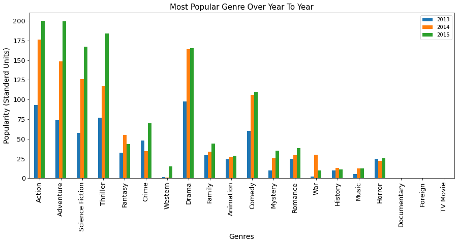

```python
#plot the bar plot of the standardised data. in last 3 years
popularity_df.iloc[:,-3:].plot(kind='bar',figsize = (15,6),fontsize=13)
#setup the title and labels of the plot.
plt.title("Most Popular Genre Over Year To Year",fontsize=15)
plt.xlabel("Genres",fontsize = 14)
plt.ylabel("Popularity (Standerd Units)",fontsize=14)
```

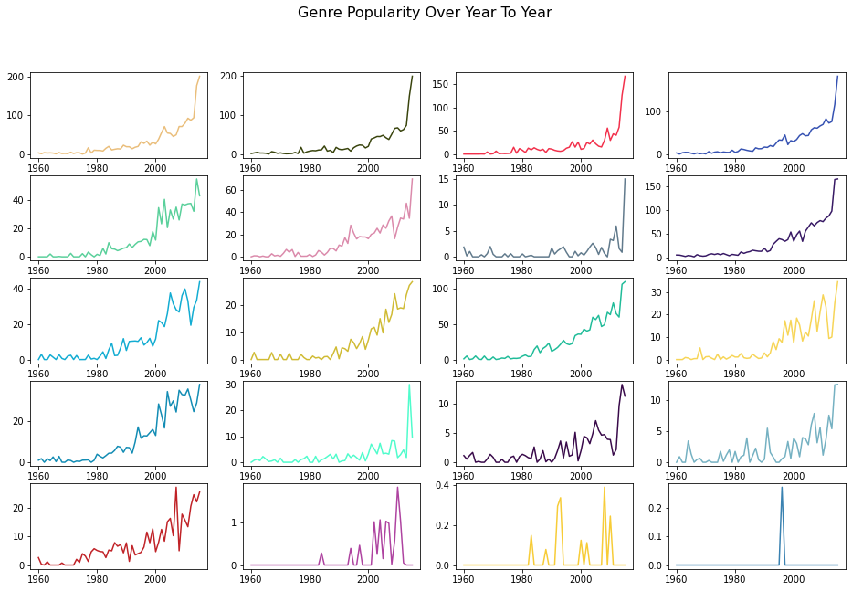

```python
#How the popularity of the genre differ year by year.
#make a subplot of size 3,3.
fig, axs = plt.subplots(5,4,figsize = (16,10))
fig.suptitle('Genre Popularity Over Year To Year',fontsize = 16)
for genre ,ax in zip(genres_list, axs.ravel()):
    popularity_df.loc[genre].plot(label = genre,ax=ax,c=np.random.rand(3,))
```

### 2. What kinds of properties are associated with movies that have high revenues?

[output not shown]

[figure not shown]

```python
# plot revenues vs some properties (budget,runtime,vot_average,Popularity,release_year)
fig,axes = plt.subplots(3,2,figsize = (16,6))
properties = ["budget","runtime","vote_average","release_year","popularity"]
fig.suptitle("Revenue Vs (budget,runtime,vot_average,Popularity,release_year)",fontsize=14)
for item,ax in zip(properties,axes.ravel()):
    movie_df.plot.scatter(x="revenue",y="budget",ax=ax,c=np.random.rand(3,))
```

### 3. Which years have the highest and lowest release of movies?

```python
# we groupy movies in every years and count them
movies_every_year = movie_df.groupby('release_year').count()['id']
movies_every_year.head()
```

```
release_year
1960     5
1961    10
1962     7
1963     6
1964     7
Name: id, dtype: int64
```

```python
#max and min
movies_every_year.max()
```

```
196
```

```python
movies_every_year.min()
```

```
4
```

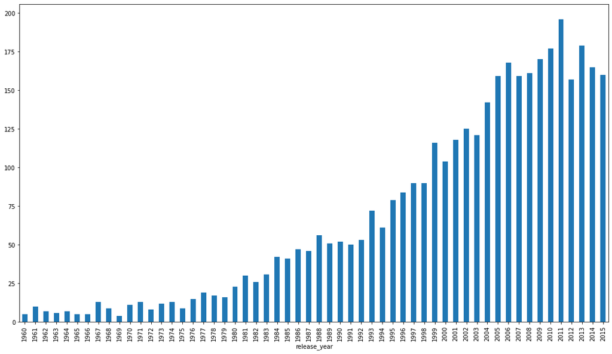

```python
#plot movie
movies_every_year.plot.bar(figsize = (18,10))
```

### 4. Which movies have Highest And Lowest Budget?

```python
#choose 20 top movie budget and plot them
top_movie_budget =movie_df.sort_values(by=['budget'],ascending=False)
top_movie_budget.head()
```

|  | index | id | popularity | budget | revenue | original_title | cast | director | runtime | genres | production_companies | release_date | vote_count | vote_average | release_year |
| --- | --- | --- | --- | --- | --- | --- | --- | --- | --- | --- | --- | --- | --- | --- | --- |
| 678 | 2244 | 46528 | 0.250540 | 425000000 | 11087569 | The Warrior's Way | Kate Bosworth\|Jang Dong-gun\|Geoffrey Rush\|Dann... | Sngmoo Lee | 100 | Adventure\|Fantasy\|Action\|Western\|Thriller | Boram Entertainment Inc. | 2010-12-02 | 74 | 6.4 | 2010 |
| 1089 | 3375 | 1865 | 4.955130 | 380000000 | 1021683000 | Pirates of the Caribbean: On Stranger Tides | Johnny Depp\|PenÃ©lope Cruz\|Geoffrey Rush\|Ian M... | Rob Marshall | 136 | Adventure\|Action\|Fantasy | Walt Disney Pictures\|Jerry Bruckheimer Films\|M... | 2011-05-11 | 3180 | 6.3 | 2011 |
| 2556 | 7387 | 285 | 4.965391 | 300000000 | 961000000 | Pirates of the Caribbean: At World's End | Johnny Depp\|Orlando Bloom\|Keira Knightley\|Geof... | Gore Verbinski | 169 | Adventure\|Fantasy\|Action | Walt Disney Pictures\|Jerry Bruckheimer Films\|S... | 2007-05-19 | 2626 | 6.8 | 2007 |
| 14 | 14 | 99861 | 5.944927 | 280000000 | 1405035767 | Avengers: Age of Ultron | Robert Downey Jr.\|Chris Hemsworth\|Mark Ruffalo... | Joss Whedon | 141 | Action\|Adventure\|Science Fiction | Marvel Studios\|Prime Focus\|Revolution Sun Studios | 2015-04-22 | 4304 | 7.4 | 2015 |
| 2230 | 6570 | 1452 | 1.957331 | 270000000 | 391081192 | Superman Returns | Brandon Routh\|Kevin Spacey\|Kate Bosworth\|James... | Bryan Singer | 154 | Adventure\|Fantasy\|Action\|Science Fiction | DC Comics\|Legendary Pictures\|Warner Bros.\|Bad ... | 2006-06-28 | 834 | 5.3 | 2006 |

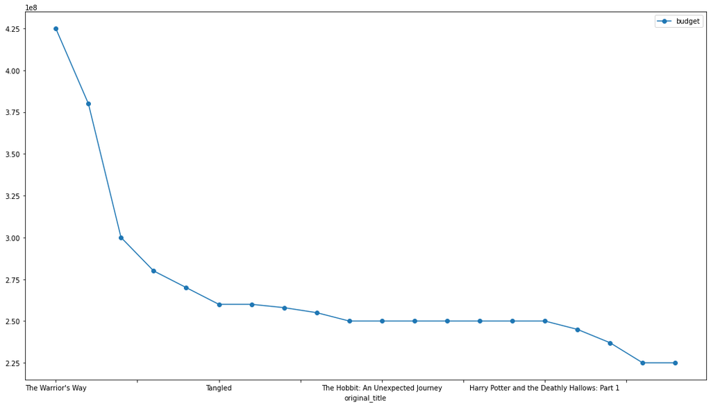

```python
#plot original_title with budget
top_movie_budget.iloc[0:20,].plot(x="original_title",y="budget",figsize = (18,10), marker='o')
```

```python
#choose 20 lowest movie budget and plot them
lowest_movie_budget =movie_df.sort_values(by=['budget'])
lowest_movie_budget.head()
```

|  | index | id | popularity | budget | revenue | original_title | cast | director | runtime | genres | production_companies | release_date | vote_count | vote_average | release_year |
| --- | --- | --- | --- | --- | --- | --- | --- | --- | --- | --- | --- | --- | --- | --- | --- |
| 805 | 2618 | 39964 | 0.090186 | 1 | 100 | Lost & Found | David Spade\|Sophie Marceau\|Ever Carradine\|Step... | Jeff Pollack | 95 | Comedy\|Romance | Alcon Entertainment\|Dinamo Entertainment | 1999-04-23 | 14 | 4.8 | 1999 |
| 1237 | 3581 | 59296 | 0.520430 | 1 | 1378 | Love, Wedding, Marriage | Mandy Moore\|Kellan Lutz\|Jessica Szohr\|Autumn F... | Dermot Mulroney | 90 | Comedy\|Romance | 120dB Films\|Scion Films\|Voodoo Production Serv... | 2011-06-03 | 55 | 5.3 | 2011 |
| 3178 | 8944 | 14373 | 0.464188 | 2 | 16 | Death Wish 2 | Charles Bronson\|Jill Ireland\|Vincent Gardenia\|... | Michael Winner | 88 | Action\|Crime\|Thriller | Cannon Films | 1982-02-20 | 27 | 5.6 | 1982 |
| 3571 | 10050 | 20701 | 0.317091 | 3 | 16 | Tales from the Darkside: The Movie | Rae Dawn Chong\|Christian Slater\|Deborah Harry\|... | John Harrison | 93 | Fantasy\|Horror\|Comedy | Paramount Pictures\|Laurel Productions\|Darkside... | 1990-05-03 | 37 | 5.8 | 1990 |
| 690 | 2398 | 39356 | 0.028456 | 3 | 43 | Boy | James Rolleston\|Craig Hall\|Taika Waititi\|Te Ah... | Taika Waititi | 87 | Drama\|Comedy | New Zealand Film Commission\|Unison Films\|Whenu... | 2010-02-14 | 26 | 7.3 | 2010 |

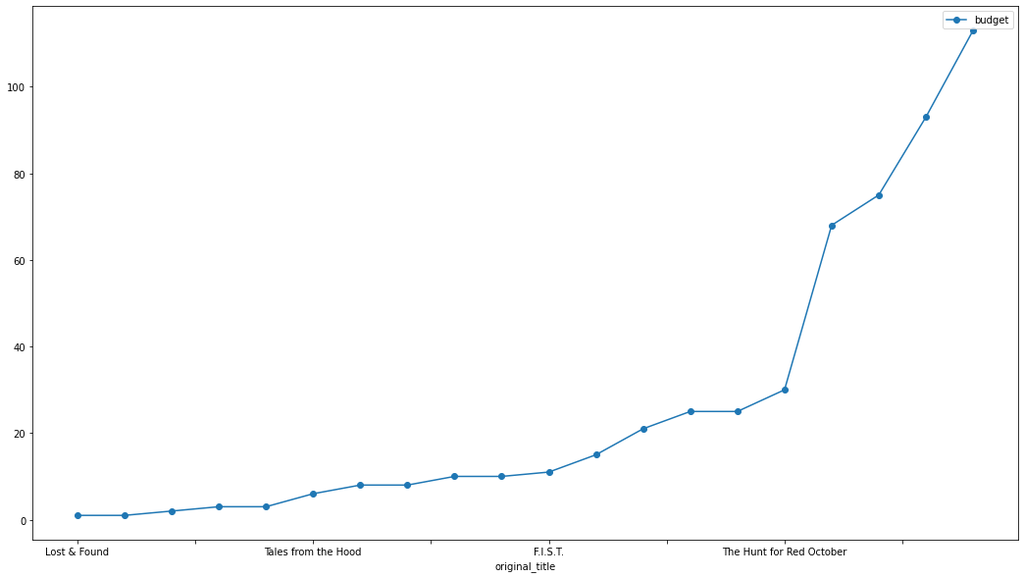

```python
#plot original_title with budget
lowest_movie_budget.iloc[0:20,].plot(x="original_title",y="budget",figsize = (18,10), marker='o')
```

```python
high_budget = movie_df.budget.max()
high_budget
```

```
425000000
```

```python
high_budget_movie = movie_df.query('budget == 425000000')['original_title']
high_budget_movie
```

```
678    The Warrior's Way
Name: original_title, dtype: object
```

```python
low_budget = movie_df.budget.min()
low_budget
```

```
1
```

```python
low_budget_movie = movie_df.query('budget == 1')['original_title']
low_budget_movie
```

```
805                Lost & Found
1237    Love, Wedding, Marriage
Name: original_title, dtype: object
```

### 5. what is the average Runtime Of Movies From Year To Year?

```python
# groupby release year
ave_runtime = movie_df.groupby('release_year').runtime.mean()
ave_runtime
```

```
release_year
1960    130.000000
1961    132.500000
1962    141.285714
1963    153.500000
1964    122.428571
1965    167.600000
1966    132.200000
1967    118.384615
1968    130.777778
1969    127.500000
1970    121.454545
1971    112.615385
1972    113.000000
1973    111.916667
```

[output cut: 43 more lines]

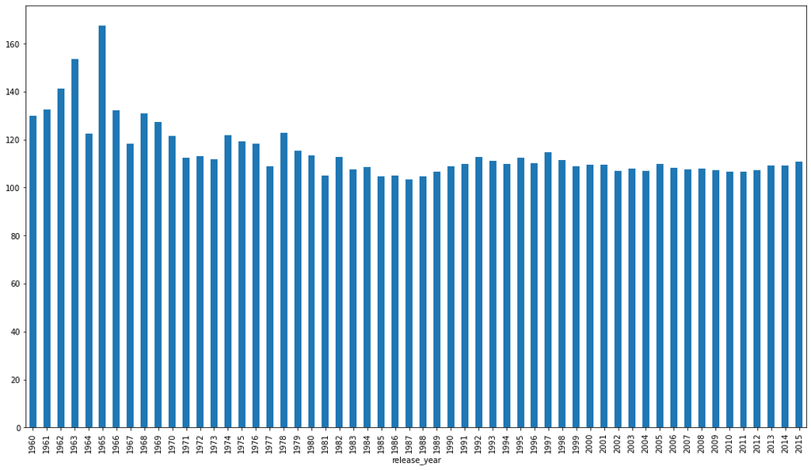

```python
ave_runtime.plot.bar(figsize = (18,10))
```

#### Limitations

> 1. During the data cleaning process, I split the data seperated by '|' into lists for easy parsing during the exploration phase. This increases the time taken in calculating the result.
> 2. In cleaning process,we remove nan and zero data so we missed some result of some movies so the result is not sure 100 percentage

```python
from subprocess import call
call(['python', '-m', 'nbconvert', 'investigate_IMDb_movie_dataSet.ipynb'])
```

```
1
```